# COM725 Assesment 2.

# Data Analysis and Visualisation of Hepatitis C Virus(HCV) Patients in Egypt

## Data Wrangling

> Data wrangling is an important process in our analysis, this involves getting data in the form that is useable. this step includes:

> Gathering Data

> This step involves collecting/selecting a dataset of choice and then I will load it into a dataframe using the pandas library.

> Assessing Data

> After loading the data in a pandas dataframe, we can now assess the data by checking its shape(i.e how many rows and columns), check for datatypes(i.e if the variable is a float, string, int or datatime), then we would also check for missing values as demonstrated in the cells below.

> Cleaning Data

> Real life data is dirty, inconsistent and incomplete, so we would need to clean the dataset if there are missing values by either deleting or replacing the values.

```python
#import libraries
import pandas as pd
import numpy as np
import matplotlib.pyplot as plt
import seaborn as sns
%matplotlib inline
```

```python
# load dataset

missing_values = ['na','--','n/a',' '] #creating a list of empty values
df = pd.read_csv('HCV-Egy-Data.csv', na_values = missing_values)
df.head()
```

|  | Age | Gender | BMI | Fever | Nausea/Vomting | Headache | Diarrhea | Fatigue & generalized bone ache | Jaundice | Epigastric pain | ... | ALT 36 | ALT 48 | ALT after 24 w | RNA Base | RNA 4 | RNA 12 | RNA EOT | RNA EF | Baseline histological Grading | Baselinehistological staging |
| --- | --- | --- | --- | --- | --- | --- | --- | --- | --- | --- | --- | --- | --- | --- | --- | --- | --- | --- | --- | --- | --- |
| 0 | 56 | 1 | 35 | 2 | 1 | 1 | 1 | 2 | 2 | 2 | ... | 5 | 5 | 5 | 655330 | 634536 | 288194 | 5 | 5 | 13 | 2 |
| 1 | 46 | 1 | 29 | 1 | 2 | 2 | 1 | 2 | 2 | 1 | ... | 57 | 123 | 44 | 40620 | 538635 | 637056 | 336804 | 31085 | 4 | 2 |
| 2 | 57 | 1 | 33 | 2 | 2 | 2 | 2 | 1 | 1 | 1 | ... | 5 | 5 | 5 | 571148 | 661346 | 5 | 735945 | 558829 | 4 | 4 |
| 3 | 49 | 2 | 33 | 1 | 2 | 1 | 2 | 1 | 2 | 1 | ... | 48 | 77 | 33 | 1041941 | 449939 | 585688 | 744463 | 582301 | 10 | 3 |
| 4 | 59 | 1 | 32 | 1 | 1 | 2 | 1 | 2 | 2 | 2 | ... | 94 | 90 | 30 | 660410 | 738756 | 3731527 | 338946 | 242861 | 11 | 1 |

5 rows × 29 columns

```python
#checking the last 5 rows
df.tail()
```

|  | Age | Gender | BMI | Fever | Nausea/Vomting | Headache | Diarrhea | Fatigue & generalized bone ache | Jaundice | Epigastric pain | ... | ALT 36 | ALT 48 | ALT after 24 w | RNA Base | RNA 4 | RNA 12 | RNA EOT | RNA EF | Baseline histological Grading | Baselinehistological staging |
| --- | --- | --- | --- | --- | --- | --- | --- | --- | --- | --- | --- | --- | --- | --- | --- | --- | --- | --- | --- | --- | --- |
| 1380 | 44 | 1 | 29 | 1 | 2 | 2 | 2 | 1 | 1 | 1 | ... | 63 | 44 | 45 | 387795 | 55938 | 5 | 5 | 5 | 15 | 4 |
| 1381 | 55 | 1 | 34 | 1 | 2 | 2 | 1 | 1 | 1 | 1 | ... | 97 | 64 | 41 | 481378 | 152961 | 393339 | 73574 | 236273 | 10 | 2 |
| 1382 | 42 | 1 | 26 | 2 | 2 | 1 | 1 | 1 | 2 | 1 | ... | 87 | 39 | 24 | 612664 | 572756 | 806109 | 343719 | 160457 | 6 | 2 |
| 1383 | 52 | 1 | 29 | 2 | 1 | 1 | 2 | 2 | 2 | 1 | ... | 48 | 81 | 43 | 139872 | 76161 | 515730 | 2460 | 696074 | 15 | 3 |
| 1384 | 55 | 2 | 26 | 1 | 2 | 2 | 2 | 1 | 2 | 1 | ... | 64 | 71 | 34 | 1190577 | 628730 | 5 | 5 | 5 | 13 | 3 |

5 rows × 29 columns

```python
# check data dimension
print('The dataset dimension is :',df.shape)
```

```
The dataset dimension is : (1385, 29)
```

```python
#checking the variable type
df.dtypes
```

```
Age                                   int64
Gender                                int64
BMI                                   int64
Fever                                 int64
Nausea/Vomting                        int64
Headache                              int64
Diarrhea                              int64
Fatigue & generalized bone ache       int64
Jaundice                              int64
Epigastric pain                       int64
WBC                                   int64
RBC                                 float64
HGB                                   int64
Plat                                float64
AST 1                                 int64
ALT 1                                 int64
ALT4                                float64
ALT 12                                int64
ALT 24                                int64
ALT 36                                int64
ALT 48                                int64
ALT after 24 w                        int64
RNA Base                              int64
RNA 4                                 int64
RNA 12                                int64
RNA EOT                               int64
RNA EF                                int64
Baseline histological Grading         int64
Baselinehistological staging          int64
dtype: object
```

```python
#checking general information of dataset
df.info()
```

```
<class 'pandas.core.frame.DataFrame'>
RangeIndex: 1385 entries, 0 to 1384
Data columns (total 29 columns):
 #   Column                            Non-Null Count  Dtype
---  ------                            --------------  -----
 0   Age                               1385 non-null   int64
 1   Gender                            1385 non-null   int64
 2   BMI                               1385 non-null   int64
 3   Fever                             1385 non-null   int64
 4   Nausea/Vomting                    1385 non-null   int64
 5   Headache                          1385 non-null   int64
 6   Diarrhea                          1385 non-null   int64
 7   Fatigue & generalized bone ache   1385 non-null   int64
 8   Jaundice                          1385 non-null   int64
 9   Epigastric pain                   1385 non-null   int64
```

[output cut: 21 more lines]

```python
#checking for empty variables
df.isnull().sum()
```

```
Age                                 0
Gender                              0
BMI                                 0
Fever                               0
Nausea/Vomting                      0
Headache                            0
Diarrhea                            0
Fatigue & generalized bone ache     0
Jaundice                            0
Epigastric pain                     0
WBC                                 0
RBC                                 0
HGB                                 0
Plat                                0
AST 1                               0
ALT 1                               0
ALT4                                0
ALT 12                              0
ALT 24                              0
ALT 36                              0
ALT 48                              0
ALT after 24 w                      0
RNA Base                            0
RNA 4                               0
RNA 12                              0
RNA EOT                             0
RNA EF                              0
Baseline histological Grading       0
Baselinehistological staging        0
dtype: int64
```

```python
#delete columns not needed
#df.drop(['AST 1','ALT 1','ALT4','ALT 12','ALT 24','ALT 36','ALT 48','ALT AFTER 24 w',''], axis = 1, inplace = True)
```

```python
#feature selection
hcv_data = df[['Age ', 'Gender', 'BMI', 'Fever','Nausea/Vomting','Headache ','Diarrhea ','Fatigue & generalized bone ache ','Jaundice ','Epigastric pain ']]
```

```python
hcv_data
```

|  | Age | Gender | BMI | Fever | Nausea/Vomting | Headache | Diarrhea | Fatigue & generalized bone ache | Jaundice | Epigastric pain |
| --- | --- | --- | --- | --- | --- | --- | --- | --- | --- | --- |
| 0 | 56 | 1 | 35 | 2 | 1 | 1 | 1 | 2 | 2 | 2 |
| 1 | 46 | 1 | 29 | 1 | 2 | 2 | 1 | 2 | 2 | 1 |
| 2 | 57 | 1 | 33 | 2 | 2 | 2 | 2 | 1 | 1 | 1 |
| 3 | 49 | 2 | 33 | 1 | 2 | 1 | 2 | 1 | 2 | 1 |
| 4 | 59 | 1 | 32 | 1 | 1 | 2 | 1 | 2 | 2 | 2 |
| ... | ... | ... | ... | ... | ... | ... | ... | ... | ... | ... |
| 1380 | 44 | 1 | 29 | 1 | 2 | 2 | 2 | 1 | 1 | 1 |
| 1381 | 55 | 1 | 34 | 1 | 2 | 2 | 1 | 1 | 1 | 1 |
| 1382 | 42 | 1 | 26 | 2 | 2 | 1 | 1 | 1 | 2 | 1 |
| 1383 | 52 | 1 | 29 | 2 | 1 | 1 | 2 | 2 | 2 | 1 |
| 1384 | 55 | 2 | 26 | 1 | 2 | 2 | 2 | 1 | 2 | 1 |

1385 rows × 10 columns

```python
hcv_data.describe()
```

|  | Age | Gender | BMI | Fever | Nausea/Vomting | Headache | Diarrhea | Fatigue & generalized bone ache | Jaundice | Epigastric pain |
| --- | --- | --- | --- | --- | --- | --- | --- | --- | --- | --- |
| count | 1385.000000 | 1385.000000 | 1385.000000 | 1385.000000 | 1385.000000 | 1385.000000 | 1385.000000 | 1385.000000 | 1385.000000 | 1385.000000 |
| mean | 46.319134 | 1.489531 | 28.608664 | 1.515523 | 1.502527 | 1.496029 | 1.502527 | 1.498917 | 1.501083 | 1.503971 |
| std | 8.781506 | 0.500071 | 4.076215 | 0.499939 | 0.500174 | 0.500165 | 0.500174 | 0.500179 | 0.500179 | 0.500165 |
| min | 32.000000 | 1.000000 | 22.000000 | 1.000000 | 1.000000 | 1.000000 | 1.000000 | 1.000000 | 1.000000 | 1.000000 |
| 25% | 39.000000 | 1.000000 | 25.000000 | 1.000000 | 1.000000 | 1.000000 | 1.000000 | 1.000000 | 1.000000 | 1.000000 |
| 50% | 46.000000 | 1.000000 | 29.000000 | 2.000000 | 2.000000 | 1.000000 | 2.000000 | 1.000000 | 2.000000 | 2.000000 |
| 75% | 54.000000 | 2.000000 | 32.000000 | 2.000000 | 2.000000 | 2.000000 | 2.000000 | 2.000000 | 2.000000 | 2.000000 |
| max | 61.000000 | 2.000000 | 35.000000 | 2.000000 | 2.000000 | 2.000000 | 2.000000 | 2.000000 | 2.000000 | 2.000000 |

## Exploratory Data Analysis

> For the EDA Process, I would be analysing the dataset to summerise their main characteristic using Statistical and visualization methods

> In the following cells, I would be doing a univariate analysis on the key features to describe them and multivariate analysis to check relationship between the features.

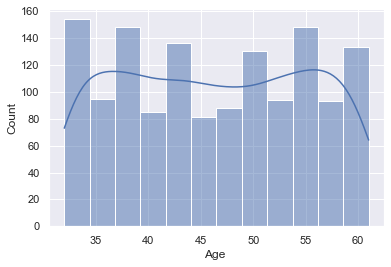

```python
# histogram plot of the age column
sns.histplot(data =hcv_data, x = 'Age ', kde=True)
```

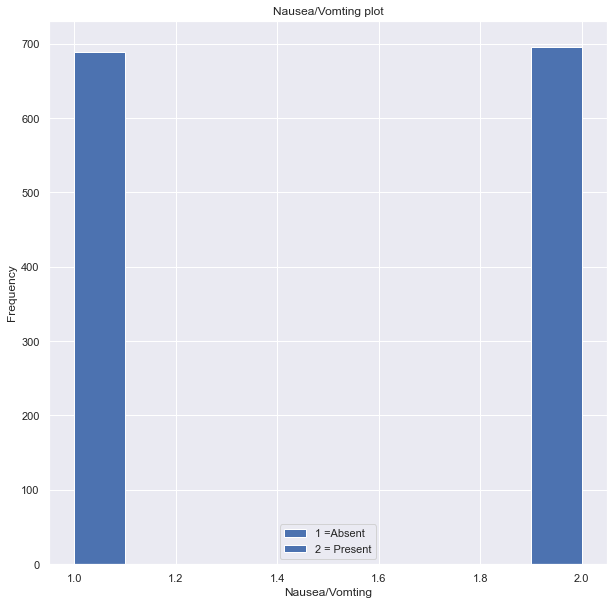

```python
# histogram plot of the Nausea/Vomting column
labels=['1 =Absent','2 = Present']
#colors =['orange', 'blue']
hcv_data['Nausea/Vomting'].plot(kind='hist',figsize=(10,10));
plt.xlabel('Nausea/Vomting')
plt.ylabel('Frequency')
plt.title('Nausea/Vomting plot')
plt.legend(labels)
plt.show()
```

[figure not shown]

```python
# histogram plot of the fever column
labels = ['Absent','present']
hcv_data['Fever'].value_counts().plot(kind='pie', figsize=(8,8), autopct='%1.0f%%');
plt.legend(labels)
plt.show()
```

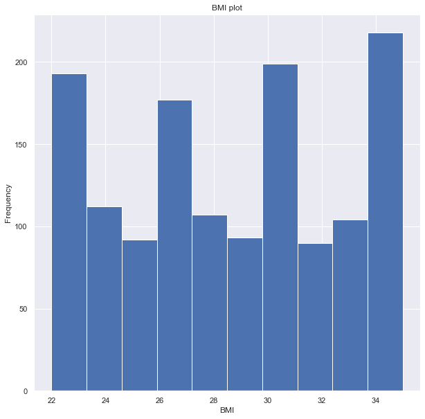

```python
# histogram plot of the BMI column
hcv_data['BMI'].plot(kind='hist',figsize=(10,10));
plt.xlabel('BMI')
plt.ylabel('Frequency')
plt.title('BMI plot')
plt.show()
```

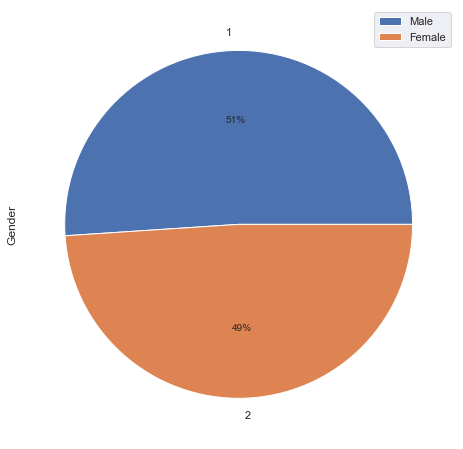

```python
# plot of the gender column
labels = ['Male','Female']
hcv_data['Gender'].value_counts().plot(kind='pie', figsize=(8,8), autopct='%1.0f%%');
plt.legend(labels)
plt.show()
```

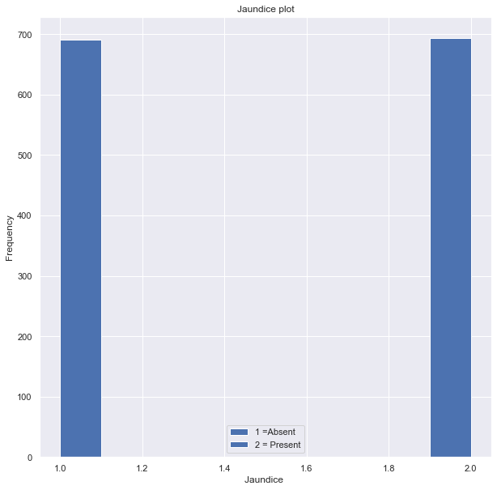

```python
# histogram plot of the Jaundice column
labels=['1 =Absent','2 = Present']
#colors =['orange', 'blue']
hcv_data['Jaundice '].plot(kind='hist',figsize=(10,10));
plt.xlabel('Jaundice ')
plt.ylabel('Frequency')
plt.title('Jaundice plot')
plt.legend(labels)
plt.show()
```

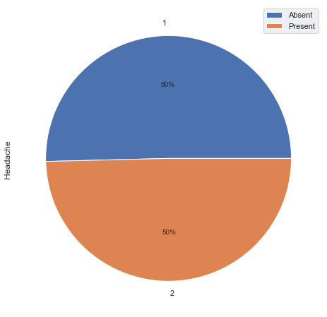

```python
# plot of the headache column
labels = ['Absent','Present']
hcv_data['Headache '].value_counts().plot(kind='pie', figsize=(8,8), autopct='%1.0f%%');
plt.legend(labels)
plt.show()
```

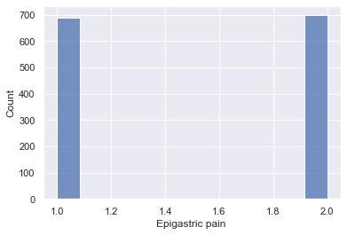

```python
# histogram plot of the epigastric pain column
sns.histplot(data =hcv_data, x = 'Epigastric pain ', legend =['1 =Absent','2 = Present'])
```

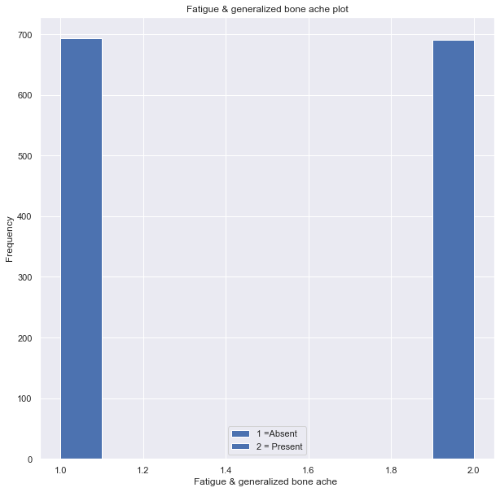

```python
# histogram plot of Fatigue & generalized bone ache column
labels=['1 =Absent','2 = Present']
#colors =['orange', 'blue']
hcv_data['Fatigue & generalized bone ache '].plot(kind='hist',figsize=(10,10));
plt.xlabel('Fatigue & generalized bone ache ')
plt.ylabel('Frequency')
plt.title('Fatigue & generalized bone ache plot')
plt.legend(labels)
plt.show()
```

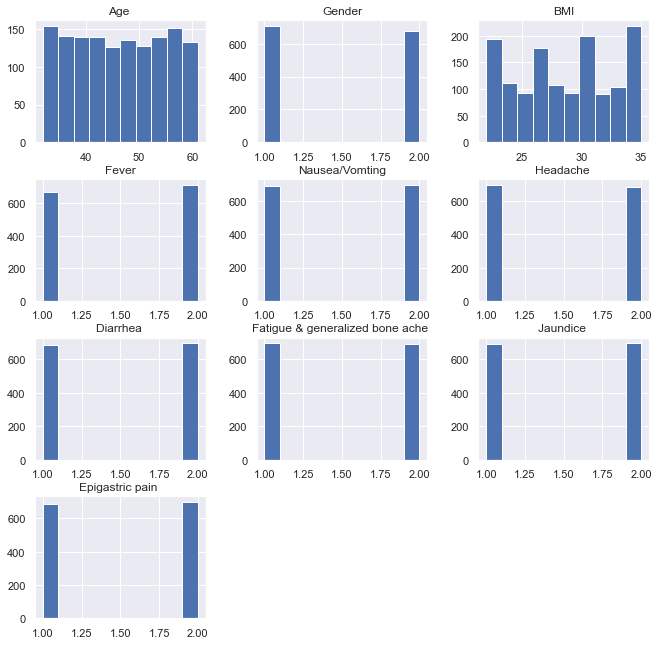

```python
# check the histogram distribution of each variable in the dataset
hcv_data.hist(figsize=(11,11));
```

```python
# checking for correlation value
hcv_data.corr()
```

|  | Age | Gender | BMI | Fever | Nausea/Vomting | Headache | Diarrhea | Fatigue & generalized bone ache | Jaundice | Epigastric pain |
| --- | --- | --- | --- | --- | --- | --- | --- | --- | --- | --- |
| Age | 1.000000 | -0.009934 | -0.025353 | -0.021208 | -0.025024 | 0.017562 | 0.043574 | -0.007817 | 0.010285 | -0.010817 |
| Gender | -0.009934 | 1.000000 | 0.006496 | 0.021604 | -0.036726 | -0.023999 | 0.018161 | 0.045452 | 0.000768 | -0.025111 |
| BMI | -0.025353 | 0.006496 | 1.000000 | -0.017581 | 0.005801 | -0.007851 | -0.026094 | -0.007296 | -0.071379 | 0.008205 |
| Fever | -0.021208 | 0.021604 | -0.017581 | 1.000000 | -0.005214 | 0.019751 | -0.019661 | -0.003545 | -0.005124 | -0.016862 |
| Nausea/Vomting | -0.025024 | -0.036726 | 0.005801 | -0.005214 | 1.000000 | 0.019536 | 0.009361 | -0.032481 | 0.000711 | -0.051306 |
| Headache | 0.017562 | -0.023999 | -0.007851 | 0.019751 | 0.019536 | 1.000000 | 0.019536 | -0.016624 | 0.007960 | 0.028224 |
| Diarrhea | 0.043574 | 0.018161 | -0.026094 | -0.019661 | 0.009361 | 0.019536 | 1.000000 | -0.026704 | -0.016618 | 0.020899 |
| Fatigue & generalized bone ache | -0.007817 | 0.045452 | -0.007296 | -0.003545 | -0.032481 | -0.016624 | -0.026704 | 1.000000 | 0.007947 | 0.036842 |
| Jaundice | 0.010285 | 0.000768 | -0.071379 | -0.005124 | 0.000711 | 0.007960 | -0.016618 | 0.007947 | 1.000000 | -0.025289 |
| Epigastric pain | -0.010817 | -0.025111 | 0.008205 | -0.016862 | -0.051306 | 0.028224 | 0.020899 | 0.036842 | -0.025289 | 1.000000 |

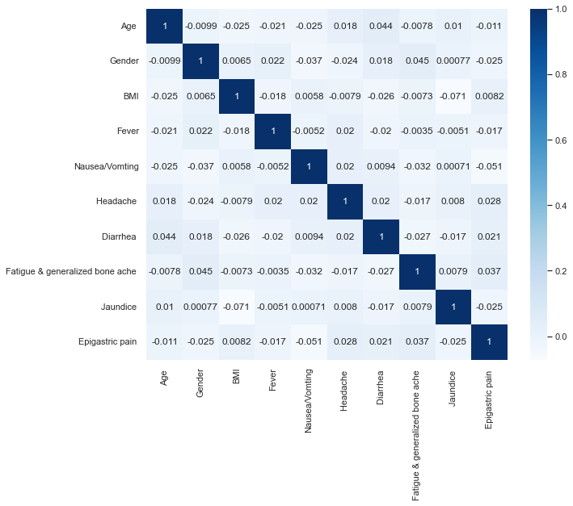

```python
#plotting heatmap of correlation
plt.figure(figsize=(10,8))
sns.set(font_scale=1)
sns.heatmap(hcv_data.corr(), annot = True, cmap ='Blues')
```